# Evaluating Baseline Characteristics of Patients with Relapsing Multiple Sclerosis

## 0.1 Preliminaries

# 1 Task 1: Data Source

This dataset is provided to me by Carrie Hersh, DO, staff neurologist at Cleveland Clinic Lou Ruvo Center for Brain Health. It is an existing database of patients with multiple sclerosis who were treated at Cleveland Clinic Mellen Center with either Dimenthyl Fumarate or Fingolimod. The original retrospective observational study comparing the efficacy both the two disease-modifying therapies was published in Mult Scler Relat Disord. 2016 Nov;10:44-52. (https://www.ncbi.nlm.nih.gov/pubmed/27919497). The subset of data used for my project 1 analysis is comprised of baseline patient demographics, radiographic and clinical disease measures.

# 2 Task 2: Load and Tidy the Data

```
Classes 'tbl_df', 'tbl' and 'data.frame':   659 obs. of  21 variables:
 $ subject_id      : int  1 2 3 4 5 6 7 8 9 10 ...
 $ age             : int  59 51 72 56 41 39 70 59 37 63 ...
 $ sex             : int  0 0 1 0 1 1 1 0 0 0 ...
 $ racen           : int  2 2 1 2 2 2 1 1 1 1 ...
 $ disease_duration: int  25 11 38 NA 13 13 31 17 6 10 ...
 $ ms_type         : int  0 0 1 0 0 0 1 0 0 0 ...
 $ prior_.drugs    : int  2 1 2 0 2 1 4 2 1 1 ...
 $ jcvirus_ab      : int  0 0 0 1 0 4 0 0 4 0 ...
 $ base_t25fw      : num  7.3 10 9.8 7.8 5.5 5.7 NA 9.5 3.8 4.3 ...
 $ base_assist     : int  0 0 2 1 0 0 NA 1 0 0 ...
 $ base_peg_d      : num  NA NA 29.6 25.4 NA 38.1 NA 18.6 NA 21 ...
 $ base_peg_nd     : num  NA NA 31.3 30.7 NA 31 NA 22.6 NA 18.7 ...
 $ base_eq5d       : int  708 708 778 708 708 508 597 778 827 800 ...
 $ base_phq9       : int  6 4 4 12 13 11 6 2 3 3 ...
 $ base_gde_c      : int  0 NA NA 0 0 0 0 0 1 1 ...
 $ base_new_t2     : int  0 0 NA 0 0 0 0 0 0 0 ...
 $ base_wbc        : num  9.62 NA 9.31 7.08 14.66 ...
 $ base_BPF        : num  0.801 NA NA 0.788 NA ...
 $ base_T2LV       : num  8.13 NA NA 69.66 NA ...
 $ base_relapse_c  : int  0 0 0 0 0 1 0 1 0 0 ...
 $ base_assist.1   : num  0 0 2 1 0 0 NA 1 0 0 ...
```

In the ‘proj1.csv’ file, there are baseline data of 659 patients with relapsing multiple sclerosis whose data were collected via electronic medical record system after instutional review board approval. Baseline information prior to being prescribed either Dimethryl Fumarate or Fingolimod were collected - these include patient demographics, disease characteristics such as duration, type, various radiographic such as lesion burden, brain parenchymal fraction, and clinical markers such as disability scores and performance scores are measured and collected.

```r
ms <- proj1 %>%
  rename(prior_drugs=prior_.drugs) %>%
  mutate(id = as.character(subject_id),
         age = as.numeric(age),
         dd=as.numeric(disease_duration),
         base_gde_c = as.integer(base_gde_c),
         base_relapse_c = as.integer(base_relapse_c),
         prior_drugs = as.integer(prior_drugs),
         sex = factor(sex,
                      levels=c(0,1),
                      labels=c("Female","Male")),
         race = factor(racen,
                       levels=c(1,2,3),
                       labels=c("White","Black", "Other")),
         ms_type = factor(ms_type,
                          levels=c(0,1),
                          labels=c("Relapsing MS","Other MS")),
         jcv = factor(jcvirus_ab,
                      levels=c(0,1,4),
                      labels=c("Negative", "Positive", "Not Tested")),
         base_assist=factor(base_assist,
                            levels=c(0, 1,2),
                            labels=c("Independent", "Cane", "Walker")),
         base_new_t2=factor(base_new_t2,
                            levels=c(0,1),
                            labels=c("No T2 Lesion", "T2 Lesions")),
         base_dis = ifelse(base_assist == "Independent",
                                  "Mild disability", "Moderate-Severe Disability"),
         base_relapse = as.factor(ifelse(base_relapse_c > 0,
                                         "Relapse", "No Relapse")),
         base_gde = as.factor(ifelse(base_gde_c > 0,
                                     "No Gad+ Lesions", "Gad+ Lesions"))) %>%
  select(id, age, sex, dd, race, ms_type, jcv, prior_drugs, base_wbc, base_assist, base_new_t2, base_dis, base_relapse, base_relapse_c, base_gde, base_gde_c, base_BPF, base_T2LV)
```

Since this is an observational study, I expect many of the variables will contain missing values since it is not the standard clinical practice to obtain values for all the baseline variables included in this study. To check missing values in this dataset, I have listed the table below indicating the number of NAs in each column

```r
map_df(ms, function(x) sum(is.na(x)))
```

```
# A tibble: 1 x 18
     id   age   sex    dd  race ms_type   jcv prior_drugs base_wbc
  <int> <int> <int> <int> <int>   <int> <int>       <int>    <int>
1     0     0     0     7     0       0     9           8       71
# ... with 9 more variables: base_assist <int>, base_new_t2 <int>,
#   base_dis <int>, base_relapse <int>, base_relapse_c <int>,
#   base_gde <int>, base_gde_c <int>, base_BPF <int>, base_T2LV <int>
```

It is conclude from this output that:

- `dd` is missing in 7 subjects
- `prior_drugs` is missing in 8 subjects
- `jcv` is missing in 9 subjects
- `base_wbc` is missing in 71 subjects
- `base_assist` and corresponding derived binary variable ‘base_dis’ are missing in 40 subjects
- `base_new_t2` missing in 18 subjects
- `base_relapse_c` and corresponding derived binary variable ‘base_relapse’ are missing in 14 subjects
- `base_gde_c` and corresponding derived binary variable ‘base_gde’ are missing in 28 subjects
- `base_BPF` is missing in 251 subjects
- `base_T2LV` is missing in 269 subjects

The rest of the variables don’t have any missing data

Since there are quite a few subjects with missing data and they may influence the final outcome analysis. It is possible that those values simply weren’t routine collected at time determiend as baseline prior to starting the studied medication, I will assume the values are missing at random for the remainder of the analysis. I will perform simple imputation as follows: for continuous variables, I will perform simple imputation based on age, sex, race, and ms_type; for non-continuous integers, I will perform simple imputation based on predictive mean matching on the bases of age, sex, race and ms_type; for categorical variables, I will replace with the mode for that variable (calculated in r).

Another tibble is then created with the derived variables based on imputed data.

```r
ms1 <- imp.1 %>%
  mutate(base_dis = as.factor(ifelse(base_assist == "Independent",
                                  "Mild disability", "Moderate-Severe Disability")),
         base_relapse = as.factor(ifelse(base_relapse_c > 0,
                                         "Relapse", "No Relapse")),
         base_gde = as.factor(ifelse(base_gde_c > 0,
                                     "No Gad+ Lesions", "Gad+ Lesions"))) %>%
  select(id, age, sex, dd, race, ms_type, jcv, prior_drugs, base_wbc, base_assist, base_new_t2, base_dis, base_relapse, base_relapse_c, base_gde, base_gde_c, base_BPF, base_T2LV)
```

# 3 Task 3: Listing of My Tibble

```r
skim(ms1)
```

```
Skim summary statistics
 n obs: 659
 n variables: 18

Variable type: character
 variable missing complete   n min max empty n_unique
       id       0      659 659   1   3     0      659

Variable type: factor
     variable missing complete   n n_unique
  base_assist       0      659 659        3
     base_dis       0      659 659        2
     base_gde       0      659 659        2
  base_new_t2       0      659 659        2
 base_relapse       0      659 659        2
          jcv       0      659 659        3
      ms_type       0      659 659        2
         race       0      659 659        3
          sex       0      659 659        2
                         top_counts ordered
  Ind: 538, Wal: 67, Can: 54, NA: 0   FALSE
          Mil: 538, Mod: 121, NA: 0   FALSE
          Gad: 497, No : 162, NA: 0   FALSE
          No : 505, T2 : 154, NA: 0   FALSE
          No : 402, Rel: 257, NA: 0   FALSE
 Neg: 409, Not: 199, Pos: 51, NA: 0   FALSE
          Rel: 508, Oth: 151, NA: 0   FALSE
  Whi: 576, Bla: 62, Oth: 21, NA: 0   FALSE
          Fem: 465, Mal: 194, NA: 0   FALSE

Variable type: integer
       variable missing complete   n mean   sd p0 p25 median p75 p100
     base_gde_c       0      659 659 0.51 1.33  0   0      0   0   11
 base_relapse_c       0      659 659 0.5  0.77  0   0      0   1    7
    prior_drugs       0      659 659 2.07 1.4   0   1      2   3    8
     hist
 ▇▁▁▁▁▁▁▁
 ▇▅▁▁▁▁▁▁
 ▇▅▃▂▁▁▁▁

Variable type: numeric
  variable missing complete   n  mean     sd    p0   p25 median   p75
       age       0      659 659 45.76 10.37  18    38     46    53
  base_BPF       0      659 659  0.84  0.035  0.68  0.82   0.84  0.86
 base_T2LV       0      659 659 15.9  15.83   0     4.96  13.06 20.84
  base_wbc       0      659 659  7.21  2.79   0.38  5.54   6.86  8.2
        dd       0      659 659 15.23  8.57   2     8.5   14    21
   p100     hist
  76    ▁▂▅▇▆▅▁▁
   0.92 ▁▁▁▂▆▇▅▁
 112.5  ▇▅▁▁▁▁▁▁
  28.2  ▁▇▅▁▁▁▁▁
  48    ▆▇▆▃▂▁▁▁
```

# 4 Task 4: Code Book

[output not shown]

# 5 Task 5: My Subjects

This data describe 659 patients selected for this retropsepctive observational study. Inclusion criteria includes patients with multiple sclerosis followed at Cleveland Clinic Mellen Center who were started on either Dimenthyl Fuamarate between 03/2013 to 07/2013 or Fingolimod between 10/2010 and 08/2011, in addition, they must have available data from 12-month follow up visit. Brain parenchymal fraction and T2 lesion volume data were obtained via automated segmentation methods after publishing date.

# 6 Task 6: My Variables

There are 18 variables in the `ms1` data set.

# 7 Task 7: My Planned Linear Regression Model

I will predict brain parenchymal fraction `base_BPF` using some combination of the following variables

- `age` - quantitative
- `sex` - binary
- `dd` - quantitative
- `race` - multi-categorical
- `ms_type` - binary
- `jcv` - multi-categorical
- `prior_drugs` - multicategorical
- `base_relapse_c` - quantitative
- `base_gde_c` - quantitative

Since bpf measures brain atrophy, which is accelrated by normal aging and high MS disease activity I predict that `age` and `dd` will have high predictive values on bpf. Other indicators of disease activity, such as `prior_drugs` (patients with more severe disease likely to have tried more drugs) and `base_relapse_c` (higher number of relapses indicate more active disease) likely will also have significant predictive value.

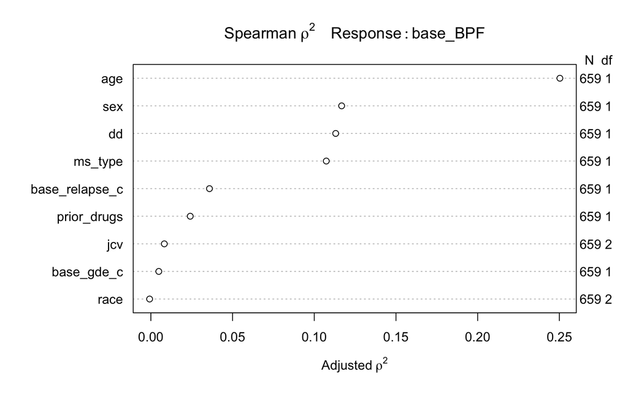

```r
plot(spearman2(base_BPF ~ age + sex + dd + race + ms_type + jcv + prior_drugs + base_relapse_c + base_gde_c, data = ms1))
```

A Spearman ρ2 plot of my predictors indicate that `age` pack the most predictive punch for a non-linear term, followed by `sex`, `dd`, and `ms_type`.

# 8 Task 8: My Planned Logistic Regression Model

I will predict level of disability, `base_dis`, using some combination of the following variables:

- `age` - quantitative
- `sex` - binary
- `dd` - quantitative
- `race` - multi-categorical
- `ms_type` - binary
- `prior_drugs` - multicategorical
- `base_relapse_c` - quantitative
- `base_new_t2` - binary
- `base_gde_c` - quantitative
- `base_T2LV` - quantitative

I predict that indicators of more active or severe disease, such as `dd`, `base_relapse_c`, `base_new_t2`, `base_gde_c`, and `base_T2LV` most likely will have more predictive value.

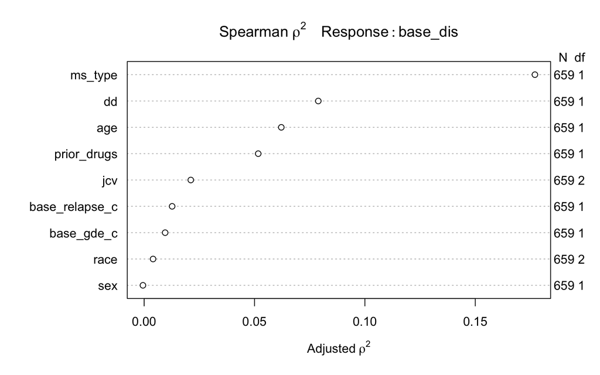

```r
plot(spearman2(base_dis ~ age + sex + dd + race + ms_type + jcv + prior_drugs + base_relapse_c + base_gde_c, data = ms1))
```

However, the Spearman ρ2 plot suggests that `ms_type` is actually the variable with most predictive punch, followed weakly by `dd`, `age`, and `prior_drugs`. The remaining variables do not seem to pack much predictive punch in predicting `base_dis`.

# 9 Task 9: Affirmation

Since this is a dataset derived from previously published work. All patient identifiers ahve been removed. I am certain that it is completely appropriate for these data to be shared with anyone, without any conditions. There are no concerns about privacy or security.

# 10 Task 10: Linear Regression

Based on the spearman plot listed in task 7, I will compare the following two models:

Model1: a, `ols` model with limited predictive variables (only including the ones with adjusted p2 above 0.10, which are `sex`, `dd`, and `ms_type`), and a non-linear restricted cubic spline with 3 knots for `age`.

Model2: an `ols` model with all the predictors, since I have a sample size of 659, there is enough room to spend a few extra DFs

There is no issue of colinearity here as suggested by relatively small VIF scores.

```
            age         sexMale              dd       raceBlack
       1.560025        1.032630        1.662601        1.039015
      raceOther ms_typeOther MS     jcvPositive   jcvNot Tested
       1.021768        1.204013        1.056338        1.117299
    prior_drugs  base_relapse_c      base_gde_c
       1.219427        1.149988        1.103053
```

Model summaries listed below along with ANOVA results; model1 followed by model 2.

```
             Effects              Response : base_BPF

 Factor                          Low  High Diff. Effect     S.E.
 age                             38.0 53   15.0  -0.0181700 0.0018659
 dd                               8.5 21   12.5  -0.0070981 0.0018802
 sex - Male:Female                1.0  2     NA  -0.0258160 0.0024093
 ms_type - Other MS:Relapsing MS  1.0  2     NA  -0.0126780 0.0027761
 Lower 0.95 Upper 0.95
 -0.021834  -0.0145060
 -0.010790  -0.0034062
 -0.030547  -0.0210850
 -0.018130  -0.0072273
```

```
                Analysis of Variance          Response: base_BPF

 Factor     d.f. Partial SS   MS           F      P
 age          2  0.0742041170 0.0371020585  47.77 <.0001
  Nonlinear   1  0.0001038985 0.0001038985   0.13 0.7147
 sex          1  0.0891786960 0.0891786960 114.81 <.0001
 dd           1  0.0110702488 0.0110702488  14.25 0.0002
 ms_type      1  0.0162003221 0.0162003221  20.86 <.0001
 REGRESSION   5  0.2980637666 0.0596127533  76.75 <.0001
 ERROR      653  0.5072022272 0.0007767262
```

```
             Effects              Response : base_BPF

 Factor                          Low  High Diff. Effect      S.E.
 age                             38.0 53   15.0  -0.01986200 0.0019422
 dd                               8.5 21   12.5  -0.00507430 0.0020221
 prior_drugs                      1.0  3    2.0  -0.00618980 0.0017144
 base_relapse_c                   0.0  1    1.0   0.00014098 0.0015025
 base_gde_c                       0.0 11   11.0  -0.01948400 0.0093735
 sex - Male:Female                1.0  2     NA  -0.02618100 0.0023954
 ms_type - Other MS:Relapsing MS  1.0  2     NA  -0.01055900 0.0028477
 race - Black:White               1.0  2     NA  -0.00381050 0.0037578
 race - Other:White               1.0  3     NA  -0.00458610 0.0061878
 jcv - Positive:Negative          1.0  2     NA  -0.00487990 0.0041413
 jcv - Not Tested:Negative        1.0  3     NA   0.00016669 0.0024866
 Lower 0.95 Upper 0.95
 -0.0236750 -0.0160480
 -0.0090450 -0.0011035
 -0.0095562 -0.0028234
 -0.0028093  0.0030913
 -0.0378900 -0.0010776
 -0.0308850 -0.0214780
 -0.0161510 -0.0049672
 -0.0111890  0.0035685
 -0.0167370  0.0075645
 -0.0130120  0.0032522
 -0.0047161  0.0050495
```

```
                Analysis of Variance          Response: base_BPF

 Factor         d.f. Partial SS   MS           F      P
 age              2  8.039345e-02 4.019672e-02  52.89 <.0001
  Nonlinear       1  5.120925e-04 5.120925e-04   0.67 0.4120
 sex              1  9.078681e-02 9.078681e-02 119.46 <.0001
 dd               1  4.785279e-03 4.785279e-03   6.30 0.0123
 ms_type          1  1.044823e-02 1.044823e-02  13.75 0.0002
 race             2  1.127101e-03 5.635507e-04   0.74 0.4768
 jcv              2  1.119871e-03 5.599356e-04   0.74 0.4790
 prior_drugs      1  9.906912e-03 9.906912e-03  13.04 0.0003
 base_relapse_c   1  6.690585e-06 6.690585e-06   0.01 0.9253
 base_gde_c       1  3.283430e-03 3.283430e-03   4.32 0.0380
 REGRESSION      12  3.143401e-01 2.619501e-02  34.47 <.0001
 ERROR          646  4.909259e-01 7.599472e-04
```

# 11 Task 11 Analysis: Logistic Regression

I chose the four highest spearman p2 value variables, `ms_type`, `dd`, `age`, `prior_drugs` as linear terms in my logistic regression model

```r
vif(lrm(base_dis ~ ms_type + dd + age + prior_drugs, data=ms1, x=TRUE, y=TRUE))
```

```
ms_type=Other MS               dd              age      prior_drugs
        1.095521         1.330963         1.351922         1.142334
```

```
Logistic Regression Model

 lrm(formula = base_dis ~ ms_type + dd + age + prior_drugs, data = ms1,
     x = TRUE, y = TRUE)

                                    Model Likelihood     Discrimination    Rank Discrim.
                                       Ratio Test           Indexes           Indexes
 Obs           659                 LR chi2     138.60    R2       0.309    C       0.824
  Mild disability538               d.f.             4    g        1.331    Dxy     0.647
  Moderate-Severe Disability121    Pr(> chi2) <0.0001    gr       3.783    gamma   0.648
 max |deriv| 2e-09                                       gp       0.185    tau-a   0.194
                                                         Brier    0.117

                  Coef    S.E.   Wald Z Pr(>|Z|)
 Intercept        -5.0533 0.6698 -7.54  <0.0001
 ms_type=Other MS  1.6745 0.2431  6.89  <0.0001
 dd                0.0336 0.0150  2.24  0.0252
 age               0.0382 0.0139  2.74  0.0062
 prior_drugs       0.2480 0.0810  3.06  0.0022
```

```
             Effects              Response : base_dis

 Factor                          Low  High Diff. Effect  S.E.
 dd                               8.5 21   12.5  0.41969 0.18744
  Odds Ratio                      8.5 21   12.5  1.52150      NA
 age                             38.0 53   15.0  0.57260 0.20903
  Odds Ratio                     38.0 53   15.0  1.77290      NA
 prior_drugs                      1.0  3    2.0  0.49598 0.16208
  Odds Ratio                      1.0  3    2.0  1.64210      NA
 ms_type - Other MS:Relapsing MS  1.0  2     NA  1.67450 0.24308
  Odds Ratio                      1.0  2     NA  5.33600      NA
 Lower 0.95 Upper 0.95
 0.052316   0.78707
 1.053700   2.19690
 0.162910   0.98229
 1.176900   2.67060
 0.178310   0.81366
 1.195200   2.25610
 1.198000   2.15090
 3.313600   8.59260
```

```
Logistic Regression Model

 lrm(formula = base_dis ~ ms_type + dd + age + prior_drugs + sex +
     race + base_relapse_c + base_new_t2 + base_gde_c + base_T2LV,
     data = ms1, x = TRUE, y = TRUE)

                                    Model Likelihood     Discrimination    Rank Discrim.
                                       Ratio Test           Indexes           Indexes
 Obs           659                 LR chi2     145.65    R2       0.323    C       0.835
  Mild disability538               d.f.            11    g        1.415    Dxy     0.670
  Moderate-Severe Disability121    Pr(> chi2) <0.0001    gr       4.117    gamma   0.670
 max |deriv| 2e-08                                       gp       0.191    tau-a   0.201
                                                         Brier    0.116

                        Coef    S.E.   Wald Z Pr(>|Z|)
 Intercept              -5.3387 0.7358 -7.26  <0.0001
 ms_type=Other MS        1.6655 0.2512  6.63  <0.0001
 dd                      0.0343 0.0157  2.19  0.0286
 age                     0.0395 0.0144  2.74  0.0061
 prior_drugs             0.2576 0.0828  3.11  0.0019
 sex=Male               -0.0753 0.2652 -0.28  0.7765
 race=Black              0.8425 0.3588  2.35  0.0189
 race=Other             -0.4262 0.8446 -0.50  0.6138
 base_relapse_c          0.0696 0.1677  0.41  0.6782
 base_new_t2=T2 Lesions -0.0045 0.3194 -0.01  0.9886
 base_gde_c              0.0065 0.1137  0.06  0.9546
 base_T2LV               0.0049 0.0071  0.69  0.4896
```

```
             Effects              Response : base_dis

 Factor                                Low    High   Diff.  Effect
 dd                                     8.500 21.000 12.500  0.4283100
  Odds Ratio                            8.500 21.000 12.500  1.5347000
 age                                   38.000 53.000 15.000  0.5921500
  Odds Ratio                           38.000 53.000 15.000  1.8079000
 prior_drugs                            1.000  3.000  2.000  0.5152600
  Odds Ratio                            1.000  3.000  2.000  1.6741000
 base_relapse_c                         0.000  1.000  1.000  0.0695740
  Odds Ratio                            0.000  1.000  1.000  1.0721000
 base_gde_c                             0.000 11.000 11.000  0.0711690
  Odds Ratio                            0.000 11.000 11.000  1.0738000
 base_T2LV                              4.962 20.844 15.882  0.0777990
  Odds Ratio                            4.962 20.844 15.882  1.0809000
 ms_type - Other MS:Relapsing MS        1.000  2.000     NA  1.6655000
  Odds Ratio                            1.000  2.000     NA  5.2883000
 sex - Male:Female                      1.000  2.000     NA -0.0753120
  Odds Ratio                            1.000  2.000     NA  0.9274500
 race - Black:White                     1.000  2.000     NA  0.8424800
  Odds Ratio                            1.000  2.000     NA  2.3221000
 race - Other:White                     1.000  3.000     NA -0.4262200
  Odds Ratio                            1.000  3.000     NA  0.6529800
 base_new_t2 - T2 Lesions:No T2 Lesion  1.000  2.000     NA -0.0045431
  Odds Ratio                            1.000  2.000     NA  0.9954700
 S.E.    Lower 0.95 Upper 0.95
 0.19567  0.044796   0.81182
      NA  1.045800   2.25200
 0.21610  0.168600   1.01570
      NA  1.183600   2.76130
 0.16567  0.190550   0.83997
      NA  1.209900   2.31630
 0.16768 -0.259080   0.39823
      NA  0.771760   1.48920
 1.25080 -2.380300   2.52260
      NA  0.092524  12.46100
 0.11261 -0.142910   0.29850
      NA  0.866830   1.34780
 0.25121  1.173100   2.15780
      NA  3.232100   8.65250
 0.26525 -0.595180   0.44456
      NA  0.551460   1.55980
 0.35880  0.139240   1.54570
      NA  1.149400   4.69130
 0.84459 -2.081600   1.22920
      NA  0.124730   3.41830
 0.31936 -0.630470   0.62139
      NA  0.532340   1.86150
```

Below are AIC and BIC values of the two models, and comparisons of the predicted made by the two models.

```
  s[c("null.deviance", "df.null")]    logLik      AIC      BIC deviance
1                               NA -244.9294 499.8589 522.3125 628.4565
2                               NA -244.9294 499.8589 522.3125 489.8589
```

```
  s[c("null.deviance", "df.null")]    logLik      AIC      BIC deviance
1                               NA -241.4018 506.8036 560.6923 628.4565
2                               NA -241.4018 506.8036 560.6923 482.8036
```

```
# A tibble: 6 x 20
  id      age sex       dd race  ms_type     jcv      prior_drugs base_wbc
  <chr> <dbl> <fct>  <dbl> <fct> <fct>       <fct>          <int>    <dbl>
1 1       59. Female  25.0 Black Relapsing … Negative           2     9.62
2 2       51. Female  11.0 Black Relapsing … Negative           1     7.42
3 3       72. Male    38.0 White Other MS    Negative           2     9.31
4 4       56. Female  17.3 Black Relapsing … Positive           0     7.08
5 5       41. Male    13.0 Black Relapsing … Negative           2    14.7
6 6       39. Male    13.0 Black Relapsing … Not Tes…           1    11.1
# ... with 11 more variables: base_assist <fct>, base_new_t2 <fct>,
#   base_dis <fct>, base_relapse <fct>, base_relapse_c <int>,
#   base_gde <fct>, base_gde_c <int>, base_BPF <dbl>, base_T2LV <dbl>,
#   A <dbl>, B <dbl>
```

```
# A tibble: 6 x 4
  id    ms_type      model prediction
  <chr> <fct>        <chr>      <dbl>
1 1     Relapsing MS A         0.188
2 2     Relapsing MS A         0.0766
3 3     Other MS     A         0.758
4 4     Relapsing MS A         0.0884
5 5     Relapsing MS A         0.0720
6 6     Relapsing MS A         0.0531
```

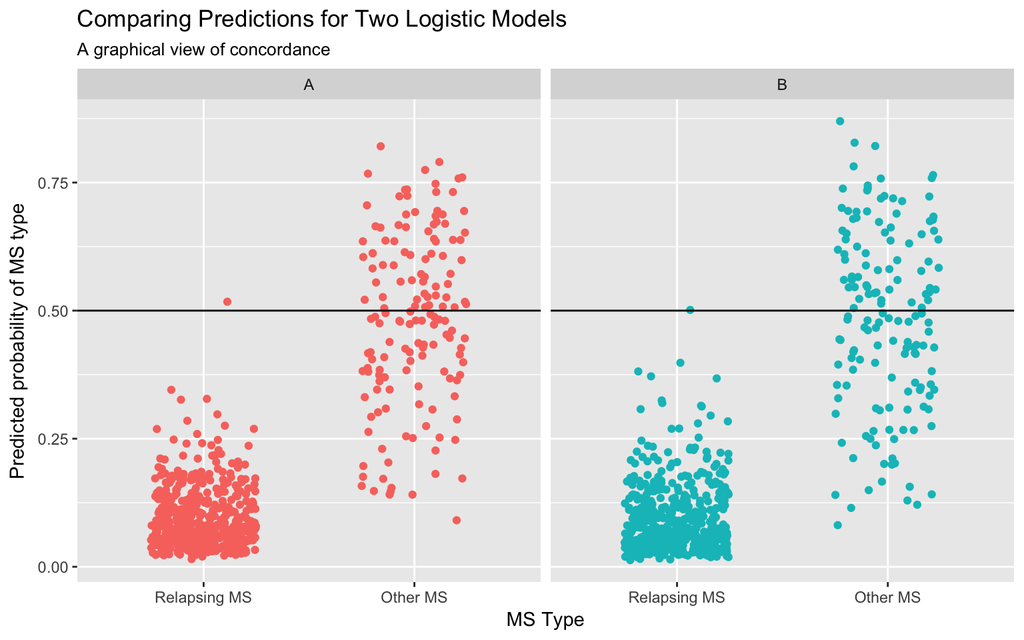

# 12 Task 12: Conclusions

To be continued…

Jenny Feng

2018-03-08 08:35:04